# Stat Computing Final Project

# Part A: Boston data set analysis

The `Boston` data set is part of the `MASS` package. Install the package to access the data.

It is a good idea to explore the data prior to or while answering the questions below.

You can answer questions in Part A with R, SAS, or a combination of both.

All plots must have intuitive titles and labels for the x- and y-axis. Variable names on the axes are fine.

### Part 1: Describe the Data

> A.1.1 Describe the data set high-level with the R help file or Google.

> A.1.2 How many observations are present? How many variables are present?

> A.1.3 What are the data types of the variables?

> A.1.4 We want to understand what factors affect home values. What is the response (ie, dependent) variable?

### Part 2: Univariate Summary

> A.2.1 Produce summary statistics for three variables: `crim`, `age`, and `medv`. Screenshot the output.

> A.2.2 With the appropriate units of measurement, interpret the median of `medv`.

> A.2.3 With the appropriate units of measurement, interpret the maximum of `age`.

> A.2.4 With the appropriate units of measurement, interpret the 1st Quartile of `crim`. “per capita” means “per person”.

> A.2.5 Plot a histogram for the variable `medv`. Screenshot the output.

> A.2.6 According to the definition below, do the data appear **normally distributed**?

**Normally distributed** data follow the bell-shaped curve. They are symmetrically distributed around the average value (i.e., the mean).

Here is a histogram of normal data produced in R:

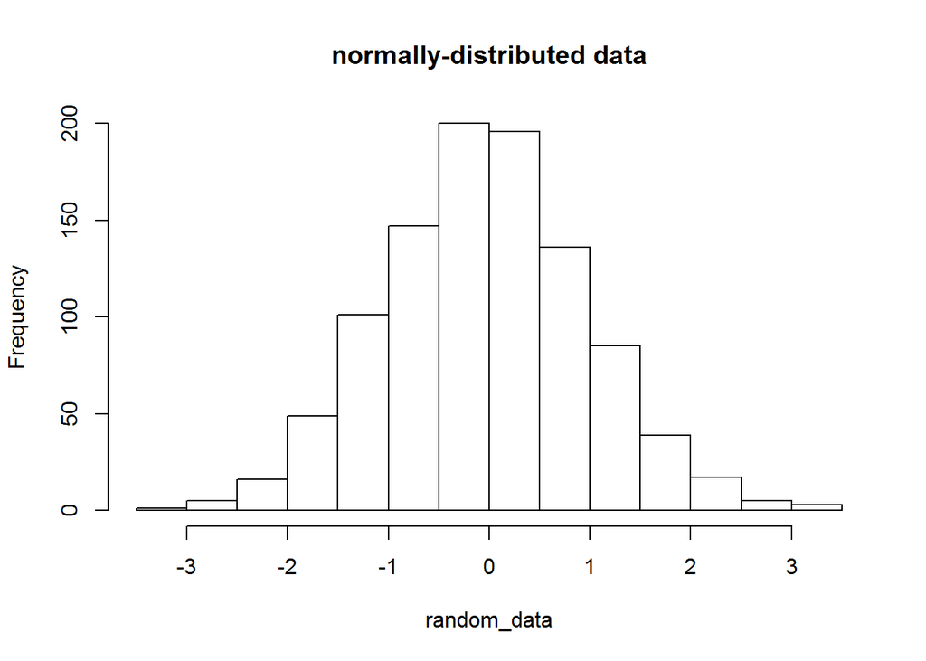

```r
random_data <- rnorm(1000)

hist(random_data, main="normally-distributed data")
```

> A.2.7 Multiply `medv` by 1,000 in order to convert it to original units. Create a histogram for this transformed variable. Screenshot the output.

> A.2.8 Did the shape of the histogram change from A.2.5?

> A.2.9 Take the natural log of `medv`. Create a histogram for this transformed variable. Screenshot the output.

> A.2.10 Do the data under the log transformation appear to be more normally distributed than the original variable?

> A.2.11 Finally, take the natural log of `medv` **after multiplying it by 1,000**. Create a histogram for this transformed variable. Screenshot the output.

> A.2.12 Did the shape of the histogram change from A.2.9? What can you conclude about the use of the log transformation on already-transformed values?

> A.2.13 Of the 4 transformations analyzed, which would you recommend to use to begin a multivariate analysis on `medv`?

### Part 3: Bivariate Summary

> A.3.1 Plot `medv*1000` on the x-axis and its log transformation on the y-axis. Screenshot the output. Briefly explain how a change in x relates to a change in y.

> A.3.2 Produce Spearman’s Rank-Order Correlation coefficient for the variables in A.3.1. Interpret the coefficient. What can we infer about the nature of the log transformation?

> A.3.3 Produce a correlation matrix with Pearson’s *r* with all variables in the data set. For the variable `medv`, use the transformation you recommend in A.2.13. Screenshot the matrix. If you use R for this process, read the notes below. Otherwise, proceed to A.3.4.

You can append (i.e., add) a column in R by:

`df$newcol <- 1:100 #adds a column to df called newcol with sequential values from 1 to 100`

Note: the new column must have the same number of values as the number of rows in the data set.

You can remove a column in R by:

`df$deleteme <- NULL #deletes the column deleteme from df`

> A.3.4 Which two variables have the strongest linear relationship with your chosen transformation of `medv`?

> A.3.5 Produce two scatter plots for each of these variables on the x-axis with the chosen transformation of `medv` on the y-axis.

> A.3.6 Based on the plots in A.3.5, are the relationships linear? Why/why not?

> A.3.7 Interpret the two relationships in everday language. Are the results intuitive? Why/why not?

# Part B: Time Series

This section is to be completed in R with the `quantmod` package.

BANA5044 students will use **two** company’s stock prices for the questions below.

BANA6043 students will use **three** company’s stock prices for the questions below.

Chose tickers for companies in different industries. Also, ensure that the companies have been publically traded for a sufficiently long period of time (i.e., greater than 3 years).

All plots must have intuitive titles and labels for the x- and y-axis. Variable names on the axes are fine.

> B.1: Use the `getSymbols()` function from the `quantmod` package to pull the stock prices for your chosen companies from Yahoo!. Use the `from=` and `to=` arguments to ensure the time series are of the same length. Use the `cbind()` function to combine the series into a matrix. Finally, pass this matrix to the `head()` and `tail()` functions, and screenshot the output.

> B.2: Plot the series, and screenshot the output.

> B.3: Produce a correlation matrix with Pearson’s *r*. Interpret the values and screenshot the output.

> B.4: By measures of correlation, do the stock prices appear to be related with one another?

> B.5: Transform the data by taking the difference of the log-transformed stock price.

The following code will output the difference of the log-transformed variable `x`.

`diff(log(x)) #where x is your variable`

> B.6: Plot the transformed series, and screenshot the output.

> B.7: Similar to B.1, use the `cbind()` function to combine the transformed series into a matrix. Finally, pass this matrix to the `head()` and `tail()` functions, and screenshot the output.

> B.8: You should see that the first value is `NA` for each transformed series. This is because R cannot compute a difference for the first observation. You will create a second matrix that removes the `NA`. There are two options, described below. After you complete this task, pass the new matrix to the `head()` and `tail()` functions, and screenshot the output.

`vec[-1] # assuming vec is a vector, this will remove the first value of the vector`

`mat[-1, ] #assuming mat is a matrix, this will remove the first row of the matrix`

> B.9: Produce a correlation matrix with Pearson’s *r* for the transformed values. Interpret the values and screenshot the output.

> B.10: By measures of correlation, does the daily growth in stock prices appear to be related with one another?

> B.11: What do your results say about the random walk hypothesis?

# Grading Schema

### BANA6043

| Section | % |
| --- | --- |
| A.1 | 10% |
| A.2 | 30% |
| A.3 | 30% |
| B | 30% |

### BANA5044

Maximum grade under BANA6043 schema or the following schema:

| Section | % |
| --- | --- |
| A.1 | 15% |
| A.2 | 40% |
| A.3 | 20% |
| B | 25% |